# 01. 인과추론 소개

## 01.01. 인과추론의 개념

- **연관관계 (Association, 상관관계)은 인과관계(Casuation)이 될 수도 있음**
  - 예) 어떤 사람이 와인을 세 잔만 마시기로 한 상황

    네 잔째 와인을 마시면 다음 날을 망칠 수 있음을 추론하였기에 이러한 결정을 내림

    $\rightarrow$ **과음 후 두통으로 잠에서 깼던 날이나, 와인을 한 잔만 마셨거나 전혀 마시지 않았는데 아무 일도 없었던 날 등의 과거경험을 바탕으로, 음주와 숙취 사이의 연관관계를 체감**

    $\rightarrow$ **음주와 숙취의 인과관계를 자연스럽게 추론**
- **전통적인 통계학에서는 '연관관계는 인과관계가 아니다'를 전제 $\rightarrow$ 그만큼 인과관계는 파악하기 까다로움**
  - 예) 주가가 급등하기 직전에 매수했거나, 폭락하기 직전에 매도한 경험

    $\rightarrow$ 시장 타이밍을 맞출 수 있다는 착각

    $\rightarrow$ 자신의 직관이 불규칙한 주가의 움직임과 인과적으로 연결되어있다는 착각 발생
- **연관관계는 두 개의 수치나 확률변수가 함께 움직이는 것**

  **인과관계는 한 변수의 변화가 다른 변수의 변화를 일으키는 것을 의미**
  - 예) 한 국가의 노벨상 수상자 수를 1인당 초콜릿 소비량과 연관시킬 때,

    두 변수가 같이 움직일 수도 있겠지만, 한 변수가 다른 변수의 원인이라고 생각하는 것은 옳지 않음

  $\rightarrow$ **연관관계가 인과관계를 의미하지 않은 이유는 쉽게 알 수 있지만, 이 둘은 동일시 되어서는 안됨**

  $\rightarrow$ **즉, 인과추론은 연관관계로부터 인관관계를 추론하고, 그리고 왜 서로 다른지 이해하는 과학**

## 01.02. 인과추론의 목적

- **인과추론의 유일한 목적은 현실을 이해하는 것**
  - 의사결정의 기준을 제시하는 것과 같은 규범적 (normative) 요소가 자주 포함
  - 예) 마케팅 비용이 매출 증가로 이어지는지 알고 싶어하는 이유는, 수익을 늘릴 수 있기 때문
- **일반적으로 원인과 결과의 관계를 알아야만, 원인에 개입하여 원하는 결과를 가져올 수 있음**

  $\rightarrow$ 인과추론을 실무에 적용하면, 의사결정 과학의 한 분야

## 01.03. 머신러닝과 인과추론

- **인과추론으로 답을 얻으려는 질문의 유형은 대부분은 '만약 (What if)'과 관련된 유형**

  **반면 머신러닝은 이러한 유형의 질문에는 답하기 쉽지 않음**
- 머신러닝은 변수 간의 연관관계를 이용해서 변수들을 다른 변수에서 예측
  - **예측에 사용하는 변수를 변경하지 않는 한, 머신러닝은 매우 잘 작동하지만**

    **개입이 동반되는 대부분의 의사결정에서, 예측모델로 목적을 달성하는 것은 매우 어려움**
  - 기업의 주요 목표 중 하나는 제품의 매출이나 사용량의 증대
  - 단순히 매출만 예측하는 머신러닝 모델은 이러한 목적에 무용
- **머신러닝을 단순한 예측도구가 아닌 강력한 모델의 도구상자라는 관점에서 접근하는 것이 바람직**

## 01.04. 연관관계와 인과관계

- 온라인 커머스 기업은 온라인 플랫폼 제품 광고에 있어, 가격 책정이나 할인 시기 같은 부분을 자율적으로 결정
  - **기간 한정 할인 캠페인을 언제, 어떻게 설정할 것인가? $\rightarrow$ 가격할인이 판매량에 미치는 영향을 파악**

    **더 많이 판매해 얻는 이익이, 더 저렴하게 판매해 얻는 손실을 상쇄할 때, 가격을 할인하면 좋다는 의사결정 가능**

  $\rightarrow$ **플랫폼을 이용하는 기업들이 가격을 할인했다면, 그렇지 않았을 때보다 더 많이 판매했을지에 대한 인과관계**
- 하지만 가격할인에 관한 인과적인 질문은, [식품, 의류, 농산물 등] 다양한 업종마다 상이할 수 있음

  $\rightarrow$ 가격 인하는 상품 유형에 따라 다른 영향을 미칠 수 있음
  - 예) 의류 기업에서 어버이날 일주일 전에 가격 인하를 공지하면 도움이 될 수 있지만, 농산물 판매 기업에는 비슷한 형태로 할인하더라도 효과가 미미

#### 장난감 기업의 데이터

- 어린이 장난감을 판매하는 기업의 12월 크리스마스 이전 기간에 대해서, 해당 기간에 가격을 할인하면 판매량이 어떻게 증가하는지 탐색
- **분석단위** (Unit of Analysis) : 인과추론 연구에서 분석단위는 일반적으로 개입(처치)하려는 대상

  $\rightarrow$ 분석단위가 기업인 데이터

```python
import pandas as pd
import numpy as np
from scipy.special import expit
import seaborn as sns
from matplotlib import pyplot as plt
from cycler import cycler
```

```python
default_cycler = (cycler(color=['0.3', '0.5', '0.7', '0.5']) +
                  cycler(linestyle=['-', '--', ':', '-.']) +
                  cycler(marker=['o', 'v', 'd', 'p']))

color=['0.3', '0.5', '0.7', '0.5']
linestyle=['-', '--', ':', '-.']
marker=['o', 'v', 'd', 'p']

plt.rc('axes', prop_cycle=default_cycler)
plt.rc('font', size=20)
```

```python
data = pd.read_csv("./data/xmas_sales.csv")
data.head(6)
```

|  | store | weeks_to_xmas | avg_week_sales | is_on_sale | weekly_amount_sold |
| --- | --- | --- | --- | --- | --- |
| 0 | 1 | 3 | 12.98 | 1 | 219.60 |
| 1 | 1 | 2 | 12.98 | 1 | 184.70 |
| 2 | 1 | 1 | 12.98 | 1 | 145.75 |
| 3 | 1 | 0 | 12.98 | 0 | 102.45 |
| 4 | 2 | 3 | 19.92 | 0 | 103.22 |
| 5 | 2 | 2 | 19.92 | 0 | 53.73 |

### 처치와 결과

- **$T_i$는 실험대상 $i$의 처치 여부**
  - **처치 (treatment)는 효과에 대한 개입 $\rightarrow$ 해당 데이터에서의 처치는 온라인 플랫폼 내 기업 중 하나의 가격할인**

  ($D$ : 인과적인 문제에 시간차원이 포함되는 경우의 처치 여부)

$$T_i = \begin{cases}1: \text{ 실험 대상 i가 처치 받은 경우}\\ 0: \text{ 실험 대상 i가 처치 받지 않은 경우}\end{cases}$$

- **영향을 주려는 변수인 주간 판매량 (`weekly_amount_sold`)는 결과 (outcome)에 해당하며, 실험 대상 $i$의 결과는 $Y_i$**
- **인과추론의 목표는 $T$가 $Y$에 미치는 영향을 학습하는 과정**

  $|rightarrow$ 할인 여부 (`is_on_sale`)가 주간 판매량 (`weekly_amount_sold`)에 미치는 효과를 파악

### 인과추론의 근본적인 문제

- **문제 : 동일한 실험 대상이 '처치'를 받은 상태와 받지 않은 상태를 동시에 관측할 수 없다는 점**
- 인과추론은 도메인 지식과 밀접한 관련이 존재
  - 상품 가격을 낮춘 상점들의 판매량이 훨씬 더 많음

    $\rightarrow$ **할인의 여부와 판매량은 연관관계이며, 인과관계가 아님**
  - **동일한 회사 (실험 대상)에서 할인이 진행되는 상황과 그렇지 않은 상황을 동시에 관측할 수 있어야만 가격할인이 판매량에 미치는 실제 효과를 확신할 수 있음**

  $\rightarrow$ **반사실 (Counterfactual) 상황을 비교함으로써 가격할인 효과를 파악할 수 있지만, 인과추론의 근본적인 문제는 동일 대상의 두 상황을 동시에 관측할 수 없음**

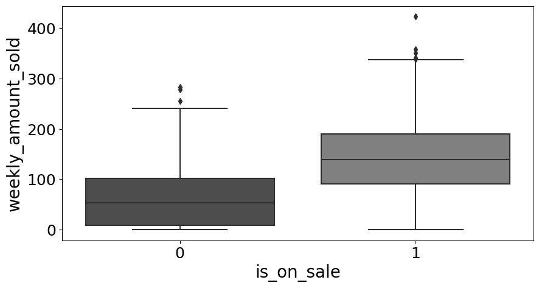

```python
fig, ax = plt.subplots(1,1, figsize=(10,5))
sns.boxplot(y="weekly_amount_sold", x="is_on_sale", data=data, ax=ax)

ax.set_xlabel("is_on_sale", fontsize = 20)
ax.set_ylabel("weekly_amount_sold", fontsize = 20)
ax.tick_params(axis='both', which='major', labelsize=18)
```

### 인과모델 (Casual Model)

- **인과모델은 화살표 $\leftarrow$로 표기하는 할당 메커니즘**
  - **등호 ($=$)가 아닌 화살표 ($\leftarrow$)는 인과관계의 비가역성 (nonreversibility)를 의미**
- $u$ :외부변수. 시스템 밖에서 주어지는 변수, 회귀분석에서의 오차항에 가까운 (관측되지 않은 모든 요인) 요인

$$T \leftarrow f_t (u_t)\\ Y \leftarrow f_y (T, u_y)$$

- 첫 번째 식 : 모델링하지 않는 변수 집합 $u_t$가 함수 $f_t$를 통해 처치변수 $T$를 유발하는 원인
- 두 번쨰 식 : 처치변수 $T$는 다른 변수 집합 $u_y$와 함께 함수 $f_y$를 통해 결과 $Y$를 유발

  **$u_y$는 결과가 단순히 처치변수만으로 결정되지 않음을 의미 $\rightarrow$ 모델링하지 않기로 선택한 변수라도, 결과에 영향을 미칠 수 있음**

  (주간 판매량 `weekly_amount_sold`는 처치에 해당하는 할인 여부 `is_on_sale` 및 특정되지 않은 요인들인 $u$때문에 발생)

  (가격할인이 모델 내에 없는 요인들 (기업 규모 등) 때문에 유발된다고 볼 수 있음)

$$IsOnSales\;\leftarrow f_1 (u_1) \\ AmountSold\;\leftarrow f_y(IsOnSales, u_y)$$

- 더 많은 변수를 사용해서 모델링을 하기 위해서는 $u$에서 변수를 꺼내어서 명시적으로 인과모델에 포함

  $\rightarrow$ 해당 변수들을 모델 안에서 설명할 수 있음
- 할인하는 경우와 할인하지 않는 경우에서 차이가 큰 경우는 대기업들이 더 공격적으로 할인을 진행할 수 있기 때문도 존재

  $\rightarrow$ 추가변수 $BuisnessSize$ 포함

$$BusinessSize \leftarrow f_s(u_s)\\IsOnSales \leftarrow f_t(BusinessSize, u_t) \\ AmountSold \leftarrow f_y(IsOnSales, BusinessSize, u_y)$$

- 첫 번째 식 :추가변수 ($BusinessSize$)를 포함하기 위해, 해당 변수가 어떻게 생성되었는지 나타내는 수식을 추가

  그다음 $BusinessSize$를 $u_t$에서 제외
- 두 번째 식 : $IsOnSales$의 원인이 $BusinessSize$와 $u_t$ (모델링하지 않기로 선택한 다른 외부변수들)임을 의미

  대기업들이 가격을 할인할 가능성이 더 높다는 의미
- 세 번째 식 : $BusinessSize$는 처치 ($IsOnSale$)와 결과 ($AmountSold$) 모두의 공통 원인

#### 회귀식 형태로의 표현

- 선형모델은 변수 $IsOnSale$과 $BusinessSize$가 선형적으로 결합한 결과로 $AmountSold$를 구성

  $\rightarrow$ **인과모델보다 더 많은 가정과, 변수 간의 관계에 함수 형태를 부여**

  **또한 독립변수인 $IsOnSale$과 $BusinessSize$가 어떻게 생성되는지는 표현하지 않음**

$$AmountSold_i = \alpha + \beta_1 IsOnSales_i + \beta_2 BusinessSize_i + e_i$$

### 개입 (Intervention)

- **인과모델이 있다면, 해당 모델을 고치고 개선하여 인과적 질문의 답을 탐색할 수 있음 $\rightarrow$ 개입**
- 모든 실험 대상이 처치 $t_0$를 받도록 하는 상황
  - $T$에 대한 자연적 원인을 제거하므로, 상수로 대체 가능

$$T \leftarrow t_0 \\ Y \leftarrow f_y (T, u_y)$$

- 인과추론에서는 개입을 $do(.)$연산자를 활용해서 표현

  ($T$에 개입해서 어떤 일이 일어날지를 추론할 때, $do(T=t_0)$로 표현
- **가격을 할인한 회사의 판매량 기댓값 $E[AmountSold|IsOnSales=1]$이 높으면,**

  **가격을 할인하도록 개입한 경우의 판매량 기댓값 $E[AmountSold|do(IsOnSales=1)]$이 과대 추정될 수 있음**

  (가격을 할인하기로 결정한 회사는 대기업일 확률이 높기 때문)

  **$E[AmountSold|do(IsOnSales=1)]$은 모든 회사가 가격을 할인하도록 통제했을 때 어떤 일이 발생했을지를 나타냄**

**중요한 것은 일반적으로 가격을 할인한 회사의 판매량에 대한 조건부 기댓값과, 할인하도록 통제한 회사의 판매량에 대한 조건 기댓값은 다르다는 것**

$$E[AmountSold|IsOnSales=1] \neq E[AmountSold|do(IsOnSales=1)]$$

#### 선택 (Selection)과 개입

- **선택 측면에서 할인이 조건으로 주어질 때는, 실제로 가격을 할인하기로 선택한 회사들의 하위 표본 판매량을 측정**
- **개입이 조건으로 주어질 때는 ($do(IsOnSales)$), 모든 회사가 가격을 할인하도록 통제한 다음, 전체 표본에서 판매량을 측정**
  - $do(.)$연산자는 관측된 데이터에서 항상 얻을 수 없는 인과 추정량 (Casual Quantity)를 정의하는데 사용

    (모든 기업이 할인하도록 강제하지 않았으므로, 모든 회사의 $do(IsOnSales=1)$인 상황을 관측할 수 없음)

    $\rightarrow$ $do(.)$ 연산자는 구하려는 인과 추정량을 분명하게 표현하는 데 사용할 수 있는 이론적 개념으로 유용
    - **대부분의 인과추론은 인과 추정량에 대한 이론적 표현에서 직접 관측할 수 없는 부분을 제어하기 위한 일련의 과정 $\rightarrow$ 식별 (Identification)**
- **즉, 선택은 처치에 따라 표본을 필터링하고, 개입은 전체 표본의 처치 여부를 통제**

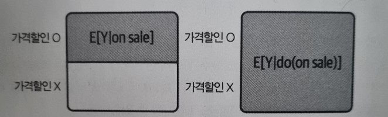

### 개별 처치효과 (Individual Treatment Effect, ITE)

- $do(.)$ 연산자를 사용하면, 개별 실험 대상 $i$에 처치가 결과에 미치는 영향인 개별 처치효과를 표현 가능

$$\tau_t = Y_i | do(T=t_1) - Y_i | do(T=t_0)$$

- 즉, 각 실험대상 $i$에 대한 처치가 $t_0$에서 $t_1$로 바뀔 떄의 효과 $\tau_t$는,

  $t_0$과 비교하여 $t_1$ 하에서의 결과 차이를 의미
- 이를 사용하여 $AmountSold$에서 $IsOnSales$를 0에서 1로 바꿀 때의 효과도 추론

$$\tau_t = AmountSold_t | do (IsOnSales = 1) - AmountSold_t | do(IsOnSales = 0)$$

- **단, 인과추론의 근본적인 문제 때문에 앞의 식 중 한가지 항에 대해서만 관측할 수 있음**

  $\rightarrow$ **따라서 이론적으로 해당 식을 표현할 수 있다고 해도, 반드시 데이터에서 이를 찾을 수 있다는 뜻은 아님**

### 잠재적 결과 (Potential Outcome)

- $do(.)$ 연산자와 함께, 인과추론에서 널리 사용하는 개념인 '반사실' 또는 '잠재적' 결과도 정의

$$Y_{ti} = Y_i |do(T_i = t)$$

- 이는 '처치가 $t$인 상태일 때, 실험대상 $i$의 결과는 $Y$가 될 것이다'를 의미하며, 함수 표기법을 사용하면

$$Y_{ti} = Y(t)_i$$

- **범주가 두 개인 이진 처치 (처치 또는 미처치)에 관해서, 처치 받지 않은 실험대상 $i$의 잠재적 결과를 $Y_{0i}$로,** **처치 받는 동일 대상 $i$의 잠재적 결과를 $Y_{ti}$로 표기한다면,**

  **관측할 수 있는 한 가지 잠재적 결과 (사실적 결과, Factual Outcome), 관측할 수 없는 다른 한 가지 결과를 반사실적 결과 (Counterfactual Outcome)**
  - 예) 실험대상 $i$가 처치 받은 후, 어떤 일이 일어나는지 사실적 결과 $Y_{1i}$를 관측

    실험대상 $i$가 처치 받지 않으면, 어떤 일이 일어날지 알 수 없음

    $\rightarrow$ 즉 $Y_{0i}$는 반사실적 결과이므로 관측할 수 없음

$$Y_i = \begin{cases}Y_{1i} : \text{실험대상 i가 처치 받은 잠재적 결과} \\ Y_{0i} : \text{같은 대상 i가 처치 받지 않은 잠재적 결과} \end{cases}\\ = T_i Y_{1i} + (1-T_i) Y_{0i} = Y_{0i} + (Y_{1i} - Y_{0i}) T_i$$

- $AmountSold_{0i}$는 회사 $I$가 가격을 할인하지 않았을 경우의 판매량이며, $AmountSold_{1i}$는 할인했을 경우의 판매량

  $\rightarrow$ **잠재적 결과에 따른 회사 $i$의 인과효과는**

$$\tau_i = Y_{1i} - Y_{0i}$$

### 일치성 및 SUTVA

- $\tau_i = Y_{1i} - Y_{0i}$은 두 가지 가정이 존재
1. **잠재적 결과가 처치와 일치성이 있어야 함**
   - 즉, $T_i = t$일 때, $Y_i(t) = Y$

     **$T$로 지정된 처치 외에 숨겨진 여러 가지 형태의 처치는 존재하지 않는다는 뜻**
   - 일치성(Consistency)가정은 두 가지 경우에 위배될 수 있음
     - **처치를 여러 번 했는데도, 그 중 일부만 고려하는 경우**

     예) 할인쿠폰이 매출에 미치는 영향에 관심이 있다고 가정할 떄,

     처치는 고객이 쿠폰을 받았는지 안 받았는지 두 가지 방식으로 간주할 수 있음

     하지만, 실제로 여러 변의 할인을 시도했다면, 일치성 가정을 위배할 수 있음
     - **처치가 잘못 정의된 경우에도 일치성 가정이 위배될 수 있음**

     예) 재무 설계사의 도움이 개인 자산에 미치는 영향에 대해서,

     '도움'의 범주를 '일회성 상담', '조언', '목표 추적' 등의 여러 범주를 하나로 묶으면, 일치성 가정을 위배할 수 있음
   - **일치성 가정 위배를 해결하려면, 분석 시 처치에 대한 모든 버전을 포함해야 함**
2. **상호 간섭 없음 (No Interference, SUTVA, Stable Uniot of Treatment Value Assumption)**
   - **즉, 하나의 실험 대상에 대한 효과는, 다른 실험 대상의 영향을 받지 않음**

   $Y_i(T_i) = Y_i(T_1, T_2, \dots, T_{i}, \dots T_{n})$
   - **파급효과 (Spillovers Effect) 또는 네트워크 효과가 있는 경우, 이러한 가정은 위배될 수 있음**
     - 백신이 전염성 질환 예방에 미치는 영향의 경우,

     한 사람에게 백신을 접종하면, 그 사람과 가까운 다른 사람들이 처치 받지 않았더라도 해당 질병에 걸릴 확률이 낮아짐
   - **이 가정을 위배하면 일반적으로 처치효과가 실제보다 작다고 생각하게 될 수 있으며,**

     **파급효과가 발생하면 대조군도 처치의 영향을 받으므로, 결국 파급효과가 없을 때보다 실험군과 대조군 간의 차이는 크게 나지 않게 됨**
   - **파급효과를 처리하려면 다른 대상에서 발생하는 효과를 포함하도록 처치효과의 정의를 확장하고, 더 유연한 모델을 사용하여 처치효과를 추정**

### 인과 추정량

- **인과추론의 근본적인 문제 : 잠재적 결과 중 하나만 관측할 수 있으므로, 개별 처치효과 ($\tau_i$)를 알 수 없음**
- 개별효과를 추정하기 위한 세 가지의 인과 추정량이 존재

#### **1. 평균 처치효과 (Average Treatment Effect, ATE) : 처치 $T$가 평균적으로 미치는 영향**

- 실험대상에 따라 더 많거나 더 적은 영향을 받을 수 있음
- 하지만, 개별대상에 미치는 영향을 알 수 없음

$$ATE = E[\tau_1] \\= E[Y_{1i} - Y_{0i}] \\ = E[Y|do(T=1)] - E[Y|do(T=0)]$$

- 데이터에서 ATE를 추정하고 싶다면, 기댓값을 표본평균으로 대체

$$\frac{1}{N} \sum^N_{i=0} \tau_i = \frac{1}{N} \sum^N_{i=0} (Y_{1i} - Y_{0i})$$

- **인과추론의 근본적인 문제로 인하여, 각 실험대상마다 잠재적 결과 중 하나만 관측되므로, 실제로 위와 같이 계산할 수는 없음**

#### 2. 실험군에 대한 평균 처치효과 (Average Treatment Effect on the Treated, ATT) : 처치 받은 대상에 대한 처치효과

$$ATT = E[Y_{1i} - Y_{0i} | T=1]$$

- 한 도시에서 진행한 오프라인 마케팅 캠페인으로, 해당 도시에서 얼마나 많은 추가 고객을 모집했는지 알고 싶을 때,

  캠페인이 진행된 도시에 대한 마케팅 효과는 $ATT$
- **$ATT$는 처치 받은 대상을 조건으로 하므로 $Y_{0i}$는 항상 관측되지 않지만, 이론적으로는 잘 정의될 수 있음**

#### 3. 조건부 평균 처치효과 (Conditional Average Treatment Effect, CATE) : 변수 $X$로 정의된 그룹에서의 처치효과

$$CATE = E[Y_{1i} - Y_{0i} | X = x]$$

- 이메일이 45세 이상의 고객과, 그보다 젊은 고객에 미치는 영향에 대하여,

  조건부 평균 처치효과는 어떤 유형의 실험대상이 개입에 더 잘 반응하는지 알 수 있어서 개인화에 유용

#### 편도함수 (Partial Derivative) : 처치변수가 연속형일 때의 인과 추정량

- 처치의 증분에 따른 $E[Y_t]$의 기대 변화량

$$\frac{\delta}{\delta} E[Y_t]$$

### 인과 추정량 계산

- 가격할인이 개별회사에 미치는 영향을 알려면, 두 가지 잠재적 결과 $AmountSold_{0i}$와 $AmountSold_{1i}$를 동시에 확인해야 함

#### 비현실적 데이터

- 인과추론의 한계로 인하여, 두 가지 잠재적 결과를 모두 볼 수 없지만,

  만약, 6개 회사의 할인 여부 데이터 (3개의 할인 진행 / 3개의 할인 미진행)가 존재할 때
  - `y`: 관측값
  - `y0` / `y1` = 실험군 / 대조군
  - `t` : 처치여부
  - `x` : 할인주간까지의 시간을 표시하는 공변량 (`x=1`은 할인주간에 수집한 데이터)

```python
df = pd.DataFrame(dict(
    i= [1,2,3,4,5,6],
    y0=[200,120,300, 450,600,600],
    y1=[220,140,400, 500,600,800],
    t= [0,0,0,1,1,1],
    x= [0,0,1,0,0,1],
)).assign(
    y = lambda d: (d["t"]*d["y1"] + (1-d["t"])*d["y0"]).astype(int),
    te=lambda d: d["y1"] - d["y0"]
)

df
```

|  | i | y0 | y1 | t | x | y | te |
| --- | --- | --- | --- | --- | --- | --- | --- |
| 0 | 1 | 200 | 220 | 0 | 0 | 200 | 20 |
| 1 | 2 | 120 | 140 | 0 | 0 | 120 | 20 |
| 2 | 3 | 300 | 400 | 0 | 1 | 300 | 100 |
| 3 | 4 | 450 | 500 | 1 | 0 | 500 | 50 |
| 4 | 5 | 600 | 600 | 1 | 0 | 600 | 0 |
| 5 | 6 | 600 | 800 | 1 | 1 | 800 | 200 |

- 가격을 할인한 회사가 어떻게 판매량을 늘렸는지에 대한 확인

$$ATE = E[AmountSold_{1i} - AmountSold_{0i}] \\ = E[AmountSold_{1i} - AmountSold_{0i} | IsOnSales =1]$$

- 가격할인으로 판매량이 평균적으로 65개 증가함을 의미

```python
df['te'].mean()
```

```
65.0
```

- $ATT$는 $T=1$일 때 마지막 열의 평균

$$ATT = E[Y_{1i} - Y_{0i} | T=1]$$

- 가격을 할인한 회사는 가격할인에 따른 판매량이 평균 83.33개 증가

```python
df.query('t==1')['te'].mean()
```

```
83.33333333333333
```

- 주간의 할인 여부가 미치는 영향

$$CATE = E[AmountSold_{1i} - AmountSold_{0i} | weeksToXmas = 0]$$

- $CATE(x=1) = 150$ / $CATE(x=0) = 22.5$

  $\rightarrow$ : 회사가 할인주간에 가격을 할인 했을 때 (22.5개 증가)보다 할인주간 1주일 전에 할인했을 때 (150개 증가)가 훨씬 더 많은 혜택을 누림

  $\rightarrow$ 가격을 일찍 할인한 매장이, 나중에 할인한 매장보다 더 많은 이득을 봄

```python
df.query('x == 1')['te'].mean()
```

```
150.0
```

```python
df.query('x == 0')['te'].mean()
```

```
22.5
```

#### 현실적 데이터

- **현실에서는 개별 처치효과를 파악할 수 없음**

  $\rightarrow$ **인과추론을 바라보는 한 가지 관점은 결측값이 있는 데이터 문제로 보는 것 $\rightarrow$ 관심있는 인과효과를 추론하려면 누락된 잠재적 결과를 대체해야 함**
- **$ATE$를 $(500+600+800)/3 - (200+120+300)/3 = 426.67$로 계산하는 것은, 인과관계를 연관관계로 혼동하여 잘못 계산한 오류**
  - **할인을 진행한 회사 (`t=1`)는 할인의 여부와 상관없이, 원래 매출이 높은 회사일 수 있기 때문**

  $\rightarrow$ 따라서 단순히 두 그룹의 평균을 비교하는 것은 처치효과 파악을 더 어렵게 만듬

```python
df = pd.DataFrame(dict(
    i= [1,2,3,4,5,6],
    y0=[200,120,300, np.nan, np.nan, np.nan,],
    y1=[np.nan, np.nan, np.nan, 500,600,800],
    t= [0,0,0,1,1,1],
    x= [0,0,1,0,0,1],
)).assign(
    y = lambda d: np.where(d["t"]==1, d["y1"], d["y0"]).astype(int),
    te=lambda d: d["y1"] - d["y0"]
)

df
```

|  | i | y0 | y1 | t | x | y | te |
| --- | --- | --- | --- | --- | --- | --- | --- |
| 0 | 1 | 200.0 | NaN | 0 | 0 | 200 | NaN |
| 1 | 2 | 120.0 | NaN | 0 | 0 | 120 | NaN |
| 2 | 3 | 300.0 | NaN | 0 | 1 | 300 | NaN |
| 3 | 4 | NaN | 500.0 | 1 | 0 | 500 | NaN |
| 4 | 5 | NaN | 600.0 | 1 | 0 | 600 | NaN |
| 5 | 6 | NaN | 800.0 | 1 | 1 | 800 | NaN |

## 01.05. 편향 (Bias)

- **편향은 인과관계와 연관관계를 다르게 만드는 요소**
- **인과분석에 존재하는 전반적인 문제는 데이터에서 추정하는 수치가, 찾으려는 인과추정량과 일치하지 않는다는 점**
- 가격할인이 기업의 판매량을 높인다는 주장에 직면했을 떄, '할인을 진행한 기업은 가격할인 없이도 어차피 매출이 원래 높았을 것'이라는 가능성을 통하여, 의문을 제기할 수 있음

  해당 기업들은 규모가 더크고 더 공격적으로 할인할 여유가 있기 때문

  $\rightarrow$ **즉, 할인한 회사(실험군)와 할인하지 않은 회사 (대조군)를 비교할 수 없음**
- $ATE$를 추정하려면, 실험군이 처치 받지 않았을 경우인 $E[Y_0|T=1]$와 대조군이 처치 받았을 경우인 $E[Y_1|T=0]$을 추정해야 함

  $ATE = E[AmountSold_{1i} - AmountSold_{0i}]$
  - 실험군과 대조군의 평균 결과를 비교할 떄, 기본적으로 $E[Y|T=0]$을 사용하여 $E[Y_0]$을 추정하고, $E[Y|T=1]$을 사용하여 $E[Y_1]$을 추정

  $\rightarrow$ 즉, $E[Y_t]$를 찾을 때, $E[Y|T=t]$를 추정하게 됨

  $\rightarrow$ **두 값이 일치하지 않는다면, 처치 $t$를 받은 실험 대상의 평균 결과인 $E[Y|T=t]$는 추정하고 싶은 $E[Y_t]$의 편향 추정량**

  ```
    - 추정량이 추정햐려는 매개변수와 다른 경우, 추정량이 표현되었다고 표현
    - 편향은 $Bias = E[\hat{\beta}-\beta]$로 정의
  ```

- **도메인 지식을 바탕으로, 가격을 할인한 회사의 $Y_0$가 할인하지 않은 회사의 $Y_0$보다 크다고 말할 수 있는 상황에서**

  (가격을 할인할 여유가 있는 회사는 할인과 관계없이 더 매출이 높은 회사인 경향)

  **일어날 수 있었지만, 일어나지 않은 일을 추론해야 함**

### 편향의 수식적 이해

- 처치와 결과 간의 연관관계는 $E[Y|T=1] - E[Y|T=0]$으로 측정 : 할인을 진행한 회사의 평균 판매량에서, 할인하지 않은 회사의 평균 판매량

  인과관계는 $E[Y_1 - Y_0] = E[Y|do(t=1)] - E[Y|do(t=0)]$으로 측정
- 실험군의 관측된 결과는 $Y_1$이고, 대조군의 결과는 $Y_0$일 때,

$$E[Y|T=1] - E[Y|T=0] = E[Y_t|T=1] - E[Y_0 | T=0]$$

- 처치 받지 않았다면, 실험군의 결과가 어떠했을 것인지 알려주는 반사실적 결과 $E[Y_0|T=1]$를 더하고 차감

$$E[Y|T=1] - E[Y|T=0] = E[Y_1|T=1] - E[Y_0|T=0] + E[Y_0|T=1] - E[Y_0|T=1]$$$$E[Y|T=1] - E[Y|T=0] = \underbrace{E[Y_1 - Y_0|T=1]}_{ATT} + \underbrace{\{ E[Y_0|T=1] - E[Y_0|T=0] \}}_{BIAS}$$

$\rightarrow$ **연관관계는 실험군에 대한 처치효과($ATT$)에 편향을 더한 값**

$\rightarrow$ **편향은 처치와 관계없이 실험군과 대조군이 어떻게 다른지에 따라 주어지고, 이는 $Y_0$의 차이로 표현**

$\rightarrow$ **할인 예제에서 $E[Y_0|T=0] < E[Y_0|T=1]$는 가격을 할인할 여력이 있는 기업이 할인여부와 관계없이 더 많이 판매하는 경향이 있음을 보여줌**

- 관측할 수 없는 많은 요소가 처치와 함께 변화하므로, 편향이 발생한다고 생각할 때,

  결과적으로 실험군과 대조군은 단순히 할인 여부 외에도 여러 가지 면에서 차이가 존재 (회사 규모, 위치, 경영방식, 할인 시기 등)

  $\rightarrow$ **가격할인으로 판매량이 얼마나 증가하는지 결정하려면, 할인한 회사와 하지 않는 회사가 평균적으로 서로 비슷해야 함**

  $\rightarrow$ **실험군과 대조군은 교환가능 해야함 (Exchangable)**

#### 와인 사례

- 적당한 와인의 음주는 건강에 좋다

  $\rightarrow$ 수명연장을 와인 때문이라고 말한다면, 와인을 마시지 않는 사람과 마시지 않는 사람을 교환할 수 있어야 하지만 불가능

  $\rightarrow$ 와인을 많이 소비하는 이탈리아, 스페인은 모두 좋은 의료 시스템을 갖춘 국가

  $\rightarrow$ 즉, $E[Lifespan_0 |WineDrinking=1] > E[Lifespan_0 |WineDrinking=0]$이므로, 편향은 실제 인과효과 추정을 어렵게 함

### 편향의 시각화

- 교환 가능성은 시각화를 통하여 확인할 수 있음
- 주간 평균 매출 `avg_week_sales`와 결과인 주간 판매량 `weekly_amount_sold`를 각각 $x$축과 $y$축으로 두고, 각점의 색상은 처치 여부 `is_on_sale`로 지정

  $\rightarrow$ 가격을 할인한 회사(실험군)이 그래프의 우측에 집중 $\rightarrow$ 할인한 회사가 더 큰 규모의 회사임을 의미

  $\rightarrow$ 할인한 회사와 할인하지 않은 회사 간에는 불균형이 존재
- 이는 $E[Y_0 | T=1] > E[Y_0|T=0]$이 맞다는 강력한 증거
  - **가격을 할인한 $T=1$ 회사 수와, 할인하지 않았을 때의 해당 회사의 결과 $Y_0$가, 모두 회사의 규모에 따라 증가하므로 상향 편향이 존재**

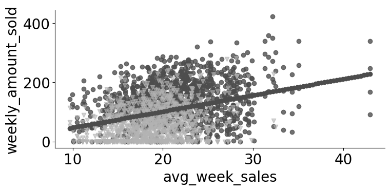

```python
# plt.rc('font', size=20)
fig = plt.figure()

sns.lmplot(data=data,ci=None,
           x="avg_week_sales", y="weekly_amount_sold",
           scatter=False, height=4, aspect=2)

plt.scatter(x=data.query("is_on_sale==1")["avg_week_sales"],
            y=data.query("is_on_sale==1")["weekly_amount_sold"],
            label="on sale", color=color[0], alpha=.8, marker=marker[0])

plt.scatter(x=data.query("is_on_sale==0")["avg_week_sales"],
            y=data.query("is_on_sale==0")["weekly_amount_sold"],
            label="not on sale", color=color[2], alpha=.6, marker=marker[1])
# plt.legend(fontsize="14")
plt.show()
```

- 가격할인과 판매량 간의 상관관계는 회사규모를 통제하면 크기가 줄어듬
- 평균매출 (회사 매출규모)가 10 이하에서, 가격할인과 판매량 간의 상관관계

```python
data.query('avg_week_sales <= 10')[['is_on_sale', 'weekly_amount_sold']].corr()
```

|  | is_on_sale | weekly_amount_sold |
| --- | --- | --- |
| is_on_sale | 1.000000 | 0.830602 |
| weekly_amount_sold | 0.830602 | 1.000000 |

- 평균매출 (회사 매출규모)가 10 이상에서, 가격할인과 판매량 간의 상관관계 $\rightarrow$ 가격할인과 판매량 간의 관계는 감소하지만, 여전히 양의 상관성을 가짐

  $\rightarrow$ 약한강도의 **심슨의 역설**

  **심슨의 역설 : 데이터의 세부 그룹별로 일정한 추세나 경향성이 나타나지만, 전체적으로 보면 그 추세가 사라지거나 반대 방향의 경향성을 나타내는 현상**

```python
data.query('avg_week_sales > 10')[['is_on_sale', 'weekly_amount_sold']].corr()
```

|  | is_on_sale | weekly_amount_sold |
| --- | --- | --- |
| is_on_sale | 1.000000 | 0.517261 |
| weekly_amount_sold | 0.517261 | 1.000000 |

```python
from sklearn.preprocessing import KBinsDiscretizer
import seaborn as sns
```

```python
LE = KBinsDiscretizer(n_bins=20, encode='ordinal', strategy='quantile')
size_ = LE.fit_transform(data[['avg_week_sales']])
data = data.assign(size=size_.reshape(-1))
```

- 만약 회사의 규모를 나타내는 변수가 존재할 때,

  할인의 여부에 따라 회사의 평균 판매량을 산점도로 표시하고, 처치여부에 따라 색을 다르게 표현한다면

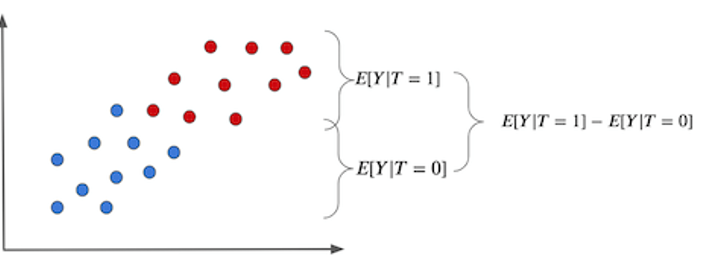

    **이러한 개별 대상의 차이는 처치받지 않은 그룹과, 받지 않은 그룹 간의 차이보다 훨씬 작으며, 이는 편향 때문**

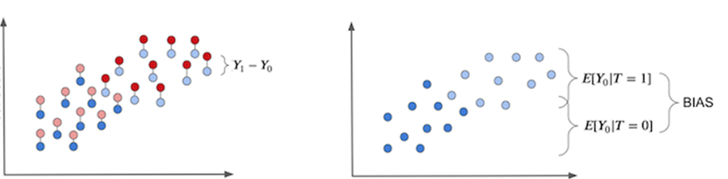

## 01.06. 인지효과 식별

- 인지효과의 식별은 분석의 첫 단계

#### 식별

- 관측할 수 있는 것은 하나의 잠재적 결과이기에, 인과 추정량은 관측할 수 없음

  $\rightarrow$ **즉, 데이터로부터 동일한 대상에 대한 차이를 관측할 수 없으므로, $E[Y_1-Y_0]$와 같은 인과 추정량을 직접 추정할 수 없음**

  $\rightarrow$ 관측 가능한 다른 수치를 찾아서, 이를 관심 있는 인과 추정량을 찾는 데 활용할 수 있으며,

  **관측 가능한 데이터에서 인과 추정량을 찾아내는 방법이 식별**
  - 예) **$E[Y|T=t]$가 $E[Y_t]$와 같아지는 데 성공했다면 ($E[Y_t]$를 식별했다면), 단순히 $E[Y|T=1] - E[Y|T=0]$을 추정하여 $E[Y_1 - Y_0]$를 구할 수 있음**

    **즉, 관측된 값인 실험군과 대조군의 평균 결과를 추정하여 관심 있는 인과 추정량을 구할 수 있음**
- **인과적 식별은 편향을 없애는 과정과 동일함**

  **즉, 잠재적 결과를 사용하여, 연관관계를 인과관계와 동일하게 만드는데 무엇이 필요한지 설명**
  - 만약 $E[Y_0|T=0] = E[Y_0|T=1]$이라면, 연관관계는 인과관계가 됨

    처치와 관계없이 대조군과 실험군이 비교 가능하며, 편향은 사라지고 실험군의 효과만 남기 때문

$$E[Y|T=1] - E[Y|T=0] = E[Y_1 - Y_0 |T=1] = ATT$$

- **실험군과 대조군이 처치에 유사하게 반응하면, ($E[Y_1 - Y_0|T=1] = E[Y_1 - Y_0 |T=0]$)**

  **평균의 차이가 평균 인과관계가 됨**

$$E[Y|T=1] - E[Y|T=0] = ATT = ATE = E[Y_1 - Y_0]$$

- **즉, 실험군과 대조군이 서로 교환가능하다면, 데이터에서 관측할 수 있는 수치로 인과관계를 표현하는 것이 간단해짐**
  - 가격을 할인한 회사와 그렇지 않은 회사가 서로 비슷하다면 (교환가능하다면), 두 그룹 간의 판매량 차이는 전적으로 가격할인 때문

### 독립성 가정 (Independence Assumption)

- 교환 가능성은 인과추론의 핵심 가정이며, 독립성 가정을 통하여 설명 가능
- **독립성 가정은 $E[Y_0 |T] = E[Y_0]$, 즉 처치가 잠재적 결과에 관한 어떠한 정보도 제공하지 않음을 의미**

  **어떤 실험 대상이 처치 받았다고 해서, 처치 받지 않았을 경우($Y_0$)의 결과가 더 낮거나 더 높음을 의미하지 않음** **(잠재적 결과가 처치와 독립)**

$$E[Y_0|T=0] = E[Y_0|T=1]$$

$\rightarrow$ 단순히 모든 회사가 할인하지 않았다면, 할인하기로 한 회사와 그렇지 않은 회사를 구분할 수 없으며,

```
모든 회사가 할인한 경우에도, 구분할 수 없음
```

$\rightarrow$ **처치여부에 관계없이 실험군과 대조군 모두 서로 비교 가능하고 구별할 수 없음**

### 랜덤화와 식별

- 인과추론 문제는 두 단계로 구분
1. 식별 : 관측 가능한 데이터로 인과 추정량을 표현하는 방법을 알아내는 단계
2. 추정 : 실제로 데이터를 사용하여 앞서 식별한 인과 추정량을 식별하는 단계
- 처치를 랜덤하게 배정할 수 있다면,

$$IsOnSales \leftarrow rand(t) \\ AmountSold \leftarrow f_y(IsOnSales, \mu_y)$$

- **처치의 랜덤화를 통하여, 인과모델에서의 외부변수 $u_t$가 사라짐**

  **또한, 실험대상에 처치가 무작위로 이루어지므로, 처치는 어떤 변수와도 독립적 $\rightarrow$ 독립성 가정을 강제적으로 만족시킴**
- 랜덤화는 처치 배정 메커니즘이 완전히 알려져 있고, 비결정적 데이터에 사용하며,

  관측은 누가 어떤 처치를 받았는지는 알 수 있지만, 처치가 어떻게 배정되었는지는 알 수 없는 데이터에 사용
- 삼각형이 실현되지 않은 잠재적 결과라고 할 때,

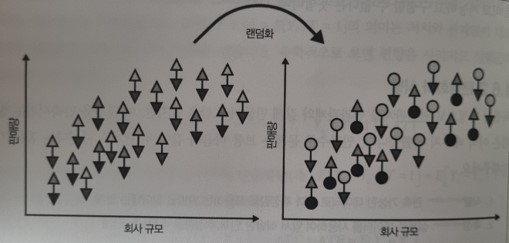

- 랜덤화 처치에 따른 데이터에서, 실현되지 않은 잠재적 결과 (삼각형)을 제거하여, 실험군과 대조군을 비교

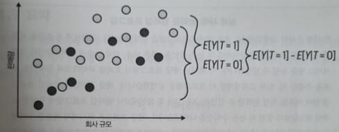

- **여기서 실험군과 대조군의 결과 차이는 평균 인지효과**

  **처치 이외에 다른 차이를 발생시키는 요인이 없기 때문**

  즉, 모든 차이는 처치 때문에 발생하며, 편향이 없음

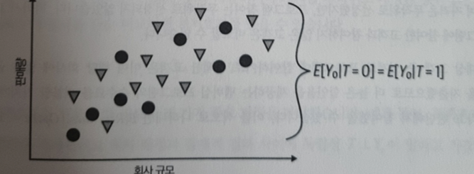

- **즉, 인과적 식별은 편향을 제거하고 실험군과 대조군을 비교할 수 있게 만드는 방법을 탐색해서**

  **눈에 보이는 모든 차이를 처치에 따른 효과로 돌리도록 하는 과정**
- 여기서 식별은 데이터 생성 과정을 알거나, 기꺼이 가정할 수 있는 경우에만 가능

  $\rightarrow$ **일반적으로 처치가 어떻게 배정되었는지 알 수 있을 때 식별이 가능**

#### 멤버십 프로그램 사례

- 온라인 커머스에서, 유료 멤버십 프로그램을 시행
  - 회원이 추가 요금을 지불해서 멤버십 프로그램에 참여하면, 더 높은 할인과 혜택
- 프로그램의 효과를 파악하고자, 무작위로 표본을 추출한 뒤, 일부 고객에게만 이 프로그램을 공개
- **해당 고객들은 멤버십 프로그램의 참여 여부를 직접 결정**

  $\rightarrow$ **멤버십 프로그램의 처치는 무작위가 아님**

  $\rightarrow$ 멤버십 프로그램에 참여하기로한 선택은, 고객의 구매율과 매출 등과 연관됨

$$E[Revenue_0|OptIn = 1] > E[Revenue_0|OptIn = 0]$$

이므로, 멤버십과 관계없이, 멤버심에 참여한 고객들은 구매율과 구매금액이 높음